# Indeed

### Grid search CV on the best parameters to tune an XgBoost model

Even this takes a reasonably long time to complete on a GPU. I will not be explaoring more options due to paucity of time.

```python
params={
    'max_depth': [6,8],
    'n_estimators': [200,400,600],
    'learning_rate':[0.05,0.1],
    'early_stopping_rounds':[8]
}
```

```python
xgb_regressor = xgb.XGBRegressor(eval_metric='rmse',tree_method='gpu_hist')

rs = GridSearchCV(xgb_regressor, params,cv=5, n_jobs=1, verbose=2)
rs.fit(X_train,y_train)

#xgb_regressor.fit(X_train,y_train,early_stopping_rounds=8)
```

```
Fitting 5 folds for each of 12 candidates, totalling 60 fits
[CV] early_stopping_rounds=8, learning_rate=0.05, max_depth=6, n_estimators=200
[CV]  early_stopping_rounds=8, learning_rate=0.05, max_depth=6, n_estimators=200 -   3.1s
[CV] early_stopping_rounds=8, learning_rate=0.05, max_depth=6, n_estimators=200
```

```
[Parallel(n_jobs=1)]: Done   1 out of   1 | elapsed:    3.1s remaining:    0.0s
```

```
[CV]  early_stopping_rounds=8, learning_rate=0.05, max_depth=6, n_estimators=200 -   3.0s
[CV] early_stopping_rounds=8, learning_rate=0.05, max_depth=6, n_estimators=200
[CV]  early_stopping_rounds=8, learning_rate=0.05, max_depth=6, n_estimators=200 -   3.0s
[CV] early_stopping_rounds=8, learning_rate=0.05, max_depth=6, n_estimators=200
[CV]  early_stopping_rounds=8, learning_rate=0.05, max_depth=6, n_estimators=200 -   3.0s
[CV] early_stopping_rounds=8, learning_rate=0.05, max_depth=6, n_estimators=200
[CV]  early_stopping_rounds=8, learning_rate=0.05, max_depth=6, n_estimators=200 -   3.0s
[CV] early_stopping_rounds=8, learning_rate=0.05, max_depth=6, n_estimators=400
[CV]  early_stopping_rounds=8, learning_rate=0.05, max_depth=6, n_estimators=400 -   5.3s
[CV] early_stopping_rounds=8, learning_rate=0.05, max_depth=6, n_estimators=400
[CV]  early_stopping_rounds=8, learning_rate=0.05, max_depth=6, n_estimators=400 -   5.5s
[CV] early_stopping_rounds=8, learning_rate=0.05, max_depth=6, n_estimators=400
[CV]  early_stopping_rounds=8, learning_rate=0.05, max_depth=6, n_estimators=400 -   5.5s
[CV] early_stopping_rounds=8, learning_rate=0.05, max_depth=6, n_estimators=400
[CV]  early_stopping_rounds=8, learning_rate=0.05, max_depth=6, n_estimators=400 -   5.5s
[CV] early_stopping_rounds=8, learning_rate=0.05, max_depth=6, n_estimators=400
[CV]  early_stopping_rounds=8, learning_rate=0.05, max_depth=6, n_estimators=400 -   5.4s
[CV] early_stopping_rounds=8, learning_rate=0.05, max_depth=6, n_estimators=600
[CV]  early_stopping_rounds=8, learning_rate=0.05, max_depth=6, n_estimators=600 -   7.9s
[CV] early_stopping_rounds=8, learning_rate=0.05, max_depth=6, n_estimators=600
[CV]  early_stopping_rounds=8, learning_rate=0.05, max_depth=6, n_estimators=600 -   7.9s
[CV] early_stopping_rounds=8, learning_rate=0.05, max_depth=6, n_estimators=600
[CV]  early_stopping_rounds=8, learning_rate=0.05, max_depth=6, n_estimators=600 -   7.9s
[CV] early_stopping_rounds=8, learning_rate=0.05, max_depth=6, n_estimators=600
[CV]  early_stopping_rounds=8, learning_rate=0.05, max_depth=6, n_estimators=600 -   7.9s
[CV] early_stopping_rounds=8, learning_rate=0.05, max_depth=6, n_estimators=600
[CV]  early_stopping_rounds=8, learning_rate=0.05, max_depth=6, n_estimators=600 -   7.9s
[CV] early_stopping_rounds=8, learning_rate=0.05, max_depth=8, n_estimators=200
[CV]  early_stopping_rounds=8, learning_rate=0.05, max_depth=8, n_estimators=200 -   7.6s
[CV] early_stopping_rounds=8, learning_rate=0.05, max_depth=8, n_estimators=200
[CV]  early_stopping_rounds=8, learning_rate=0.05, max_depth=8, n_estimators=200 -   7.6s
[CV] early_stopping_rounds=8, learning_rate=0.05, max_depth=8, n_estimators=200
[CV]  early_stopping_rounds=8, learning_rate=0.05, max_depth=8, n_estimators=200 -   7.6s
[CV] early_stopping_rounds=8, learning_rate=0.05, max_depth=8, n_estimators=200
[CV]  early_stopping_rounds=8, learning_rate=0.05, max_depth=8, n_estimators=200 -   7.6s
[CV] early_stopping_rounds=8, learning_rate=0.05, max_depth=8, n_estimators=200
[CV]  early_stopping_rounds=8, learning_rate=0.05, max_depth=8, n_estimators=200 -   7.6s
[CV] early_stopping_rounds=8, learning_rate=0.05, max_depth=8, n_estimators=400
[CV]  early_stopping_rounds=8, learning_rate=0.05, max_depth=8, n_estimators=400 -  14.6s
[CV] early_stopping_rounds=8, learning_rate=0.05, max_depth=8, n_estimators=400
```

[output cut: 62 more lines]

```
[CV]  early_stopping_rounds=8, learning_rate=0.1, max_depth=8, n_estimators=400 -  14.0s
[CV] early_stopping_rounds=8, learning_rate=0.1, max_depth=8, n_estimators=400
[CV]  early_stopping_rounds=8, learning_rate=0.1, max_depth=8, n_estimators=400 -  13.9s
[CV] early_stopping_rounds=8, learning_rate=0.1, max_depth=8, n_estimators=400
[CV]  early_stopping_rounds=8, learning_rate=0.1, max_depth=8, n_estimators=400 -  14.0s
[CV] early_stopping_rounds=8, learning_rate=0.1, max_depth=8, n_estimators=600
[CV]  early_stopping_rounds=8, learning_rate=0.1, max_depth=8, n_estimators=600 -  20.7s
[CV] early_stopping_rounds=8, learning_rate=0.1, max_depth=8, n_estimators=600
[CV]  early_stopping_rounds=8, learning_rate=0.1, max_depth=8, n_estimators=600 -  20.7s
[CV] early_stopping_rounds=8, learning_rate=0.1, max_depth=8, n_estimators=600
[CV]  early_stopping_rounds=8, learning_rate=0.1, max_depth=8, n_estimators=600 -  20.7s
[CV] early_stopping_rounds=8, learning_rate=0.1, max_depth=8, n_estimators=600
[CV]  early_stopping_rounds=8, learning_rate=0.1, max_depth=8, n_estimators=600 -  20.6s
[CV] early_stopping_rounds=8, learning_rate=0.1, max_depth=8, n_estimators=600
[CV]  early_stopping_rounds=8, learning_rate=0.1, max_depth=8, n_estimators=600 -  20.6s
```

```
[Parallel(n_jobs=1)]: Done  60 out of  60 | elapsed:  9.9min finished
```

```
GridSearchCV(cv=5, error_score='raise',
       estimator=XGBRegressor(base_score=0.5, booster='gbtree', colsample_bylevel=1,
       colsample_bytree=1, eval_metric='rmse', gamma=0, learning_rate=0.1,
       max_delta_step=0, max_depth=3, min_child_weight=1, missing=None,
       n_estimators=100, n_jobs=1, nthread=None, objective='reg:linear',
       random_state=0, reg_alpha=0, reg_lambda=1, scale_pos_weight=1,
       seed=None, silent=True, subsample=1, tree_method='gpu_hist'),
       fit_params={}, iid=True, n_jobs=1,
       param_grid={'max_depth': [6, 8], 'n_estimators': [200, 400, 600], 'learning_rate': [0.05, 0.1], 'early_stopping_rounds': [8]},
       pre_dispatch='2*n_jobs', refit=True, scoring=None, verbose=2)
```

```python
print('\n Best estimator:')
print(rs.best_estimator_)
xgb_regressor=rs.best_estimator_
```

```
 Best estimator:
XGBRegressor(base_score=0.5, booster='gbtree', colsample_bylevel=1,
       colsample_bytree=1, early_stopping_rounds=8, eval_metric='rmse',
       gamma=0, learning_rate=0.05, max_delta_step=0, max_depth=6,
       min_child_weight=1, missing=None, n_estimators=600, n_jobs=1,
       nthread=None, objective='reg:linear', random_state=0, reg_alpha=0,
       reg_lambda=1, scale_pos_weight=1, seed=None, silent=True,
       subsample=1, tree_method='gpu_hist')
```

#### Print the metrics for the XgBoost model

```python
output_xgb = xgb_regressor.predict(X_test)
metrics(np.exp(y_test),np.exp(output_xgb))
```

```
MAPE 0.13225305023908265
RMSE: 18.26810593127189
Mean absolute error: 14.967276311598527
Mean Bias 0.8717462749491894
```

#### Plot the feature importance graph

```python
sorted_idx = np.argsort(xgb_regressor.feature_importances_)[::-1]
feature_importance={}
for index in sorted_idx:
    feature_importance[train_one_hot.drop(['companyId'],axis=1).columns[index]]= xgb_regressor.feature_importances_[index]
```

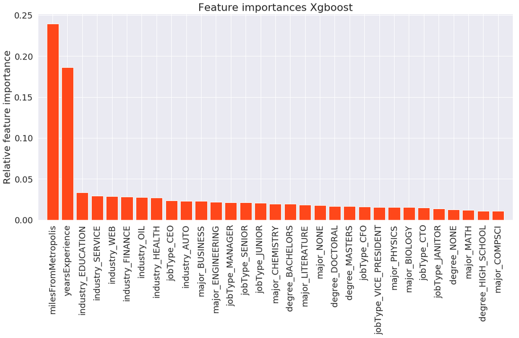

```python
ss = sorted(feature_importance, key=feature_importance.get, reverse=True)
top_names = ss[0:]
n_features=len(top_names)
f=plt.figure(figsize=(18,8))
plt.grid(True)
plt.title("Feature importances Xgboost",fontsize=22)
plt.bar(range(n_features), [feature_importance[i] for i in top_names], color="#ff471a", align="center")
plt.xlim(-1, n_features)
plt.ylabel('Relative feature importance',fontsize=20)
plt.yticks(fontsize=18)
plt.xticks(range(n_features), top_names, rotation=90,fontsize=18)
f.savefig("feauture_importance.pdf", bbox_inches='tight')
```

### CatBoost

I am not going tune the Catboost model using Grid search (since it is proof of concept). I will be using the same parameters the Grid search found for XgBoost. In fact I am keeping the number of iterations to 200 since even this is an overkill based on the loss shown below.

```python
print(train.info())
categorical_features_indices = np.where(train.dtypes != np.float)[0]
categorical_features_indices
```

```
<class 'pandas.core.frame.DataFrame'>
Int64Index: 799996 entries, 12940 to 482226
Data columns (total 6 columns):
companyId              799996 non-null object
degree                 799996 non-null object
major                  799996 non-null object
industry               799996 non-null object
yearsExperience        799996 non-null float64
milesFromMetropolis    799996 non-null float64
dtypes: float64(2), object(4)
memory usage: 42.7+ MB
None
```

```
array([0, 1, 2, 3])
```

```python
model_catboost=CatBoostRegressor(iterations=200, depth=6, learning_rate=0.05, loss_function='RMSE')
model_catboost.fit(train, train_label,cat_features=categorical_features_indices,eval_set=(test, test_label),plot=True)
```

```
0:	learn: 4.4731672	test: 4.4724304	best: 4.4724304 (0)	total: 431ms	remaining: 1m 25s
1:	learn: 4.2507402	test: 4.2500124	best: 4.2500124 (1)	total: 822ms	remaining: 1m 21s
2:	learn: 4.0394742	test: 4.0387492	best: 4.0387492 (2)	total: 1.17s	remaining: 1m 16s
3:	learn: 3.8388445	test: 3.8381259	best: 3.8381259 (3)	total: 1.54s	remaining: 1m 15s
4:	learn: 3.6483201	test: 3.6476197	best: 3.6476197 (4)	total: 1.89s	remaining: 1m 13s
5:	learn: 3.4673875	test: 3.4667014	best: 3.4667014 (5)	total: 2.27s	remaining: 1m 13s
6:	learn: 3.2955688	test: 3.2948927	best: 3.2948927 (6)	total: 2.65s	remaining: 1m 13s
7:	learn: 3.1324306	test: 3.1317578	best: 3.1317578 (7)	total: 2.95s	remaining: 1m 10s
8:	learn: 2.9775580	test: 2.9768966	best: 2.9768966 (8)	total: 3.16s	remaining: 1m 6s
9:	learn: 2.8305451	test: 2.8298913	best: 2.8298913 (9)	total: 3.46s	remaining: 1m 5s
10:	learn: 2.6909016	test: 2.6902494	best: 2.6902494 (10)	total: 3.81s	remaining: 1m 5s
11:	learn: 2.5583571	test: 2.5577132	best: 2.5577132 (11)	total: 4.15s	remaining: 1m 5s
12:	learn: 2.4325835	test: 2.4319377	best: 2.4319377 (12)	total: 4.49s	remaining: 1m 4s
13:	learn: 2.3131615	test: 2.3125158	best: 2.3125158 (13)	total: 4.69s	remaining: 1m 2s
14:	learn: 2.1998590	test: 2.1992256	best: 2.1992256 (14)	total: 5.05s	remaining: 1m 2s
15:	learn: 2.0923021	test: 2.0916774	best: 2.0916774 (15)	total: 5.42s	remaining: 1m 2s
16:	learn: 1.9902653	test: 1.9896478	best: 1.9896478 (16)	total: 5.78s	remaining: 1m 2s
17:	learn: 1.8928422	test: 1.8922551	best: 1.8922551 (17)	total: 6.15s	remaining: 1m 2s
18:	learn: 1.8005638	test: 1.8000036	best: 1.8000036 (18)	total: 6.25s	remaining: 59.5s
19:	learn: 1.7128688	test: 1.7123330	best: 1.7123330 (19)	total: 6.42s	remaining: 57.8s
20:	learn: 1.6297048	test: 1.6291978	best: 1.6291978 (20)	total: 6.63s	remaining: 56.5s
21:	learn: 1.5507945	test: 1.5503101	best: 1.5503101 (21)	total: 6.86s	remaining: 55.5s
22:	learn: 1.4759435	test: 1.4754841	best: 1.4754841 (22)	total: 7.14s	remaining: 54.9s
23:	learn: 1.4050207	test: 1.4044720	best: 1.4044720 (23)	total: 7.34s	remaining: 53.8s
24:	learn: 1.3377204	test: 1.3370770	best: 1.3370770 (24)	total: 7.56s	remaining: 52.9s
25:	learn: 1.2739666	test: 1.2732369	best: 1.2732369 (25)	total: 7.75s	remaining: 51.9s
26:	learn: 1.2135999	test: 1.2128927	best: 1.2128927 (26)	total: 7.88s	remaining: 50.5s
27:	learn: 1.1563896	test: 1.1556004	best: 1.1556004 (27)	total: 8.02s	remaining: 49.2s
28:	learn: 1.1021532	test: 1.1013876	best: 1.1013876 (28)	total: 8.27s	remaining: 48.8s
29:	learn: 1.0509382	test: 1.0501953	best: 1.0501953 (29)	total: 8.32s	remaining: 47.1s
30:	learn: 1.0023197	test: 1.0015022	best: 1.0015022 (30)	total: 8.47s	remaining: 46.2s
31:	learn: 0.9563670	test: 0.9555699	best: 0.9555699 (31)	total: 8.64s	remaining: 45.3s
32:	learn: 0.9129034	test: 0.9120943	best: 0.9120943 (32)	total: 8.73s	remaining: 44.2s
33:	learn: 0.8718315	test: 0.8710404	best: 0.8710404 (33)	total: 8.88s	remaining: 43.3s
34:	learn: 0.8331061	test: 0.8323366	best: 0.8323366 (34)	total: 8.94s	remaining: 42.1s
35:	learn: 0.7964485	test: 0.7956987	best: 0.7956987 (35)	total: 9.06s	remaining: 41.3s
36:	learn: 0.7618632	test: 0.7610541	best: 0.7610541 (36)	total: 9.18s	remaining: 40.4s
37:	learn: 0.7291550	test: 0.7283686	best: 0.7283686 (37)	total: 9.36s	remaining: 39.9s
38:	learn: 0.6976521	test: 0.6968315	best: 0.6968315 (38)	total: 9.56s	remaining: 39.5s
39:	learn: 0.6679550	test: 0.6670941	best: 0.6670941 (39)	total: 9.7s	remaining: 38.8s
```

[output cut: 148 more lines]

```
188:	learn: 0.2560880	test: 0.2561539	best: 0.2561539 (188)	total: 40.9s	remaining: 2.38s
189:	learn: 0.2560838	test: 0.2561495	best: 0.2561495 (189)	total: 41.1s	remaining: 2.16s
190:	learn: 0.2560796	test: 0.2561452	best: 0.2561452 (190)	total: 41.2s	remaining: 1.94s
191:	learn: 0.2560743	test: 0.2561399	best: 0.2561399 (191)	total: 41.5s	remaining: 1.73s
192:	learn: 0.2560716	test: 0.2561363	best: 0.2561363 (192)	total: 41.7s	remaining: 1.51s
193:	learn: 0.2560658	test: 0.2561304	best: 0.2561304 (193)	total: 42s	remaining: 1.3s
194:	learn: 0.2560579	test: 0.2561219	best: 0.2561219 (194)	total: 42.2s	remaining: 1.08s
195:	learn: 0.2560526	test: 0.2561173	best: 0.2561173 (195)	total: 42.4s	remaining: 866ms
196:	learn: 0.2560468	test: 0.2561106	best: 0.2561106 (196)	total: 42.6s	remaining: 649ms
197:	learn: 0.2560432	test: 0.2561071	best: 0.2561071 (197)	total: 42.8s	remaining: 433ms
198:	learn: 0.2560371	test: 0.2561004	best: 0.2561004 (198)	total: 43s	remaining: 216ms
199:	learn: 0.2560347	test: 0.2560984	best: 0.2560984 (199)	total: 43.3s	remaining: 0us

bestTest = 0.2560984138
bestIteration = 199
```

```
<catboost.core.CatBoostRegressor at 0x7f2d010961d0>
```